# North Carolina State Climate Office

# OCDS Advanced Track Tutorial

## Tutorial Learning Goals

We will be tackling these objectives:

- *Define* open data and reproducible science
- *Recognize* the importance of statistical analysis for climate data analysis using cloud based data
- *Apply* techniques to access and explore publicly available climate data from the cloud using exploratory data analysis (i.e. tidyverse)
- *Create* a machine learning model to predicts results for a representative case study

### Meet Mr. Wuf!

Mr. Wuf works for Mount Mitchell State Park in Burnsville, NC and was recently asked by his boss to write a report summarizing rainfall and temperature data for 2021. This report will be used to help optimize 2022 event planning (e.g., fall color viewing) for park visitors and maintenance scheduling for park staff. He recently got promoted to the head office of the NC State Climate office! Mr. Wuf’s wife, Mrs. Wuf, recently told him about the State Climate Office of North Carolina’s new nClimgrid and Econet data portals. He agrees with her that it would be a great opportunity to check out these new, free tools. After some preliminary sleuthing around nClimgrid, he discovered there was a Monthly U.S Climate Gridded Dataset (nClimGrid; https://www.ncei.noaa.gov/access/metadata/landing-page/bin/iso?id=gov.noaa.ncdc:C00332). How did he miss this? Once he downloads these data from nClimGrid and Econet, Mr. Wuf plans to put the skills he learned in an online R programming course to the test for this real-world, work-related project.

## Importing Data

### API Introduction

- API is the acronym for Application Programming Interface that enables applications to exchange data and functionality easily and securely.
- The API data that we will be using is called nClimgrid which consists of four climate variables derived from the GHCN-Dataset: maximum temperature, minimum temperature, average temperature, and precipitation.

### nClimgrid Data Set

```r
## Read in data from AWS nClimGrid 2020-2021
nclim_2020s<-read_csv('https://noaa-nclimgrid-daily-pds.s3.amazonaws.com/EpiNOAA/decadal/2020-2021-ste-decadal.csv')%>%drop_na()
## Read in nClimGrid 2010-2019
nclim_2010s<-fread('https://noaa-nclimgrid-daily-pds.s3.amazonaws.com/EpiNOAA/decadal/2010-2019-ste-decadal.csv')%>%drop_na()
```

```r
#If computation time takes a while ... we have   a .Rda file
load("NCLIM2010.Rda")
load("NCLIM2020.Rda")
```

## Functions/Cleaning

### Combining Data Sets

```r
## Lets quickly combind the data sets to get a data set ranging from the above
## lets also filter for data record that pertain to North Carolina
nclim <- rbind(nclim_2020s,nclim_2010s)%>%filter(state == c("North Carolina", "South Carolina"))
```

```r
## Using the whole data set, subset values to only look at the years 2019 to 2020
## We will be using this data set for k-means clustering later
## Call the data set nclimk
## This data set will have 34 thousand objects

nclimk_raw<-nclim_2020s%>%filter(date >= "2020-01-01" & date <="2020-12-31")%>%filter(state == c("North Carolina", "South Carolina"))
```

### Functions

Using the formula $(C \times \frac{9}{5}) + 32=F$, covert the temperature to Fahrenheit.

```r
#create a function for basic syntax
# convert data value temperature F to C
# Call it CtoF
CtoF<- function(datcols){
  x<- (9/5)*datcols+32
  return(x)
}
```

We now will need to apply this function to the temperature columns.

```r
#apply the fucntion  CtoF with tidyverse functions
# to the coloumns relating to tempurature
colnames(nclim)
```

```
##  [1] "date"        "year"        "month"       "day"         "state"
##  [6] "region_code" "PRCP"        "TAVG"        "TMIN"        "TMAX"
```

```r
nclim[8:10]<- nclim[8:10]%>% lapply(CtoF)
head(nclim)
```

```
## # A tibble: 6 x 10
##   date        year month   day state         region_code  PRCP  TAVG  TMIN  TMAX
##   <date>     <dbl> <chr> <dbl> <chr>         <chr>       <dbl> <dbl> <dbl> <dbl>
## 1 2020-01-01  2020 01        1 North Caroli~ 31           0     45.1  34.4  55.8
## 2 2020-01-03  2020 01        3 North Caroli~ 31           9.65  47.9  38.1  57.7
## 3 2020-01-05  2020 01        5 North Caroli~ 31           4.39  47.9  34.8  61.0
## 4 2020-01-07  2020 01        7 North Caroli~ 31           0.56  44.4  31.2  57.6
## 5 2020-01-09  2020 01        9 North Caroli~ 31           0     43.1  29.7  56.5
## 6 2020-01-11  2020 01       11 North Caroli~ 31           2.2   54.5  44.7  64.3
```

### Cleaning

```r
## Apply Tidyverse piping to easily add degree labels  to the end of certain coloumns for temp
## and to add units for precipitation
colnames(nclim)[8:10]<-colnames(nclim)[8:10]%>%tolower()%>% paste0("_degf")
colnames(nclim)[7]<-colnames(nclim)[7]%>%tolower()%>% paste0("_cm")

head(nclim)
```

```
## # A tibble: 6 x 10
##   date        year month   day state     region_code prcp_cm tavg_degf tmin_degf
##   <date>     <dbl> <chr> <dbl> <chr>     <chr>         <dbl>     <dbl>     <dbl>
## 1 2020-01-01  2020 01        1 North Ca~ 31             0         45.1      34.4
## 2 2020-01-03  2020 01        3 North Ca~ 31             9.65      47.9      38.1
## 3 2020-01-05  2020 01        5 North Ca~ 31             4.39      47.9      34.8
## 4 2020-01-07  2020 01        7 North Ca~ 31             0.56      44.4      31.2
## 5 2020-01-09  2020 01        9 North Ca~ 31             0         43.1      29.7
## 6 2020-01-11  2020 01       11 North Ca~ 31             2.2       54.5      44.7
## # ... with 1 more variable: tmax_degf <dbl>
```

```r
## Keep the weather data coloumns as well as the date, drop all other coloumns
## Further Create the variable ifRain: a factor to indicate wether it rained on a certain day
## Call this final data set nclimf

nclimf <- nclim %>% select(date,prcp_cm,tavg_degf,tmin_degf,tmax_degf,state)%>%
                    mutate(ifNC=as.factor(as.integer(state=="North Carolina")))%>%
                    mutate(ifRain= as.factor(as.integer(prcp_cm>0)))%>%
                    select(-state)


head(nclimf)
```

```
## # A tibble: 6 x 7
##   date       prcp_cm tavg_degf tmin_degf tmax_degf ifNC  ifRain
##   <date>       <dbl>     <dbl>     <dbl>     <dbl> <fct> <fct>
## 1 2020-01-01    0         45.1      34.4      55.8 1     0
## 2 2020-01-03    9.65      47.9      38.1      57.7 1     1
## 3 2020-01-05    4.39      47.9      34.8      61.0 1     1
## 4 2020-01-07    0.56      44.4      31.2      57.6 1     1
## 5 2020-01-09    0         43.1      29.7      56.5 1     0
## 6 2020-01-11    2.2       54.5      44.7      64.3 1     1
```

### Cleaning for nclimk

Below we do the same cleaning and data preparation that we did for nclim, with the exclusion of the ifNC variable. This is because we will be looking at all of the data

```r
### below we do the same cleaning for nlcimk
#apply the ufnction CtoF with tidyverse
nclimk_raw[8:10]<- nclimk_raw[8:10]%>% lapply(CtoF)

## Apply Tidyverse piping to easily add degree labels  to the end of certain coloumns for temp
## and to add units for precipitation
colnames(nclimk_raw)[8:10]<-colnames(nclimk_raw)[8:10]%>%tolower()%>% paste0("_degf")
colnames(nclimk_raw)[7]<-colnames(nclimk_raw)[7]%>%tolower()%>% paste0("_cm")

nclimk <- nclimk_raw %>% select(date,prcp_cm,tavg_degf,tmin_degf,tmax_degf)%>%
                    mutate(ifRain= as.factor(as.integer(prcp_cm>0)))



#viewing the data for k-means
head(nclimk)
```

```
## # A tibble: 6 x 6
##   date       prcp_cm tavg_degf tmin_degf tmax_degf ifRain
##   <date>       <dbl>     <dbl>     <dbl>     <dbl> <fct>
## 1 2020-01-01    0         45.1      34.4      55.8 0
## 2 2020-01-03    9.65      47.9      38.1      57.7 1
## 3 2020-01-05    4.39      47.9      34.8      61.0 1
## 4 2020-01-07    0.56      44.4      31.2      57.6 1
## 5 2020-01-09    0         43.1      29.7      56.5 0
## 6 2020-01-11    2.2       54.5      44.7      64.3 1
```

## EDA

- We will inspect the data through a couple graphs as well as a simple linear regression

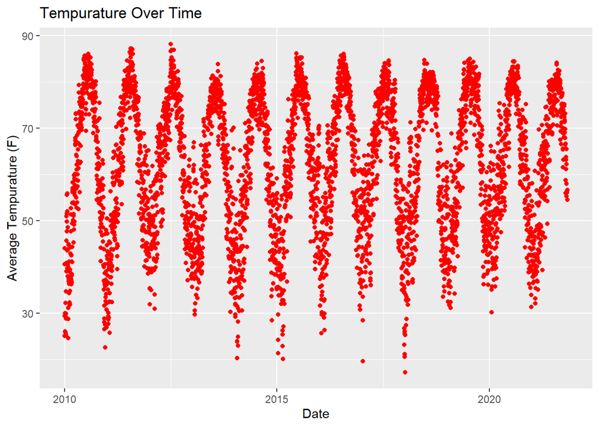

```r
# scatterplot of avg tempurature vs time, color the points red
## add labels
## save the plot at plotOTemp
plotOtemp<-ggplot(nclim,aes(x=date,y=tavg_degf))+geom_point(colour="red")+labs(x = "Date", y = "Average Tempurature (F)",title ="Tempurature Over Time")
plotOtemp
```

## Machine Learning

### Simple Regression

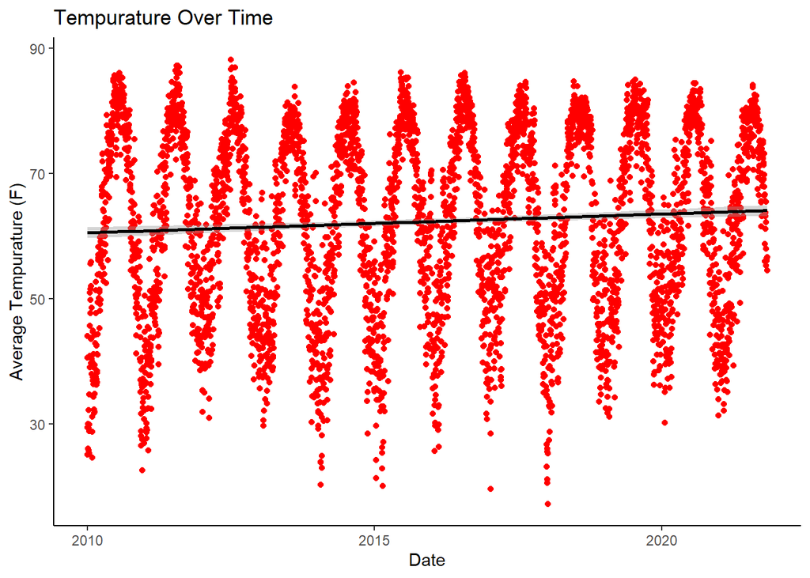

```r
plotOtemp+geom_smooth(method="lm",se=TRUE,col = "black")+theme_classic()
```

### Time Series Analysis

- A time series is a collection of observations of well-defined data items obtained through repeated measurements over time
- Time series analyze a sequence of data points collected over an interval of times
- We will now try to fit a time series model to this data rather than a regression to see if the results improve. We will create a time series forecast with ARIMA (Auto Regressive Integrated Moving Average).
- First we begin by creating an xts object

```r
## with the variables date and average temperature, create a time series object.
## save as temp_ts
temp_ts<-xts(nclimf$tavg_degf,nclim$date)
```

- Now we will split the data into a training and testing set. Majority of the data will be in the training set.

```r
# train/validation split
train_date <- nclimf$date[round(nrow(temp_ts) *0.7)]
train <- temp_ts[index(temp_ts) <= train_date]
test <- temp_ts[index(temp_ts) > train_date]
```

- Next we plot the time series object we created to take a closer look at the data

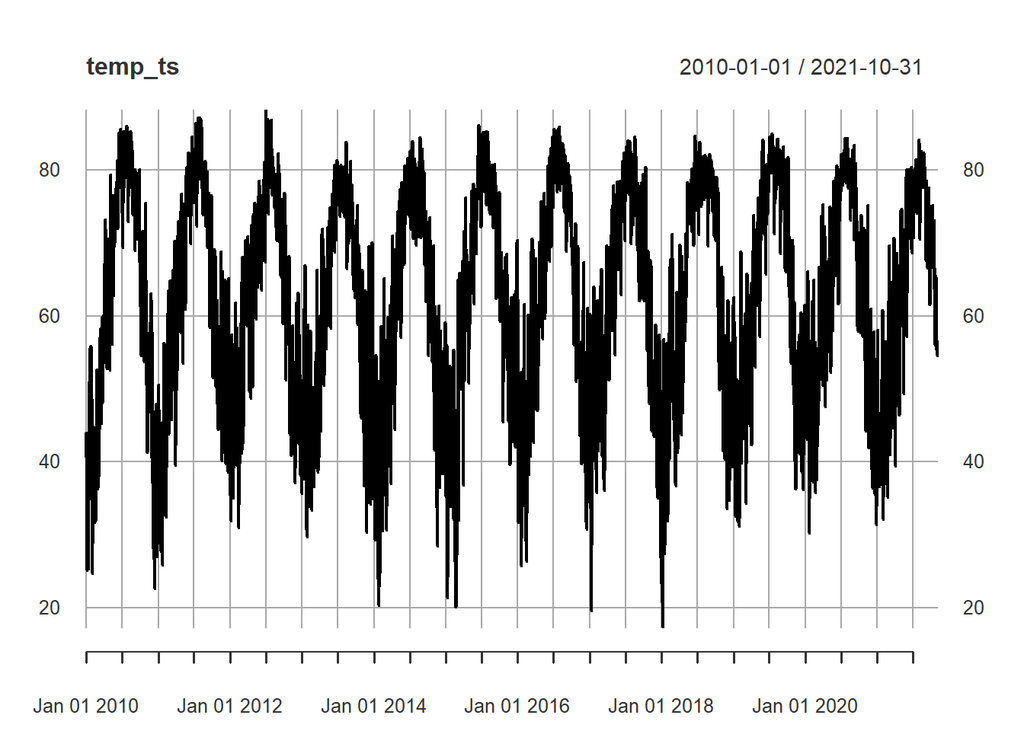

```r
# plot the time series object we called temp_ts
plot(temp_ts)
```

### Time to build the model!

```r
# build the time series model
model_ts <- auto.arima(as.vector(train))
model_ts
```

```
## Series: as.vector(train)
## ARIMA(4,0,0) with non-zero mean
##
## Coefficients:
##          ar1     ar2      ar3     ar4     mean
##       0.6543  0.3227  -0.3118  0.2889  61.5179
## s.e.  0.0195  0.0227   0.0228  0.0195   2.4412
##
## sigma^2 = 31.12:  log likelihood = -7570.51
## AIC=15153.02   AICc=15153.06   BIC=15187.75
```

- Once the model has been created, we will use that to create a forecasting xts object

```r
# plot validation data with forecast on top of plot
forecast <- forecast(model_ts, h=length(test))
forecast_dates <- seq(train_date, length = length(test), by="day")

forecast_xts <- xts(forecast$mean, order.by=forecast_dates)
```

- Finally we plot the validation (testing) data and layer the forecast on top for our time series model

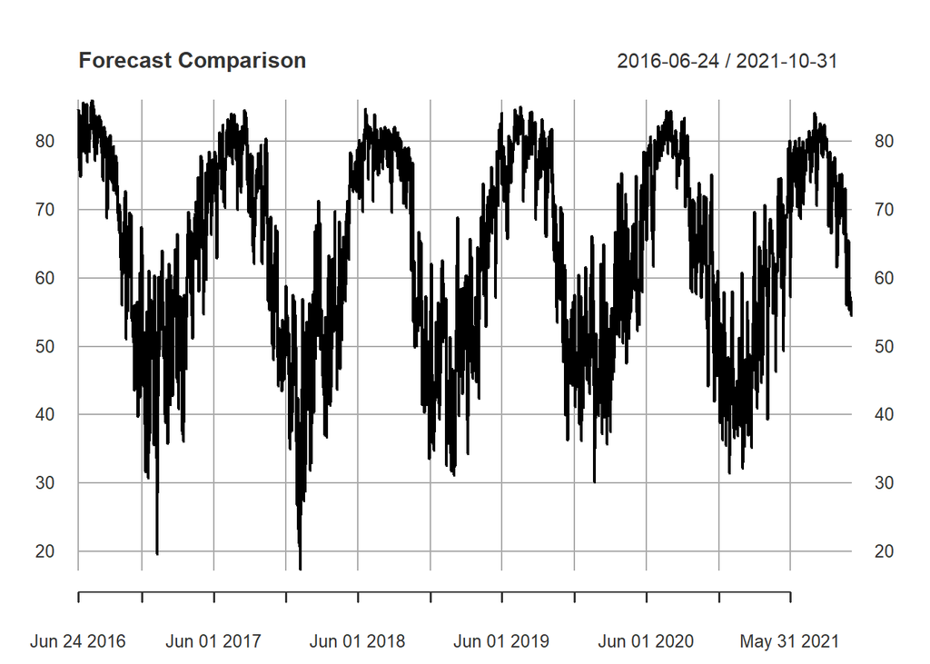

```r
plot(test, main = 'Forecast Comparison')
```

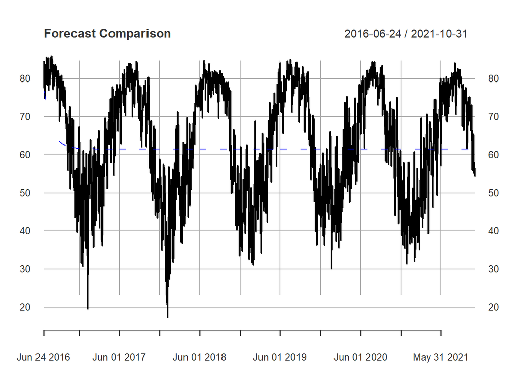

```r
lines(forecast_xts, col="blue")
```

### K-Means Clustering in nClimGridData

#### Creating Functions

- We want to create a function that can do a complicated process in as few steps as possible.
- `calculate_cluster` is the name of the function we are going to create to compute k-means clusters among other information.

```r
calculate_cluster <- function(data, k) {
  x <- data %>%
    na.omit() %>%
    scale()

  df <- kmeans(x, center = k) %>%
    augment(data) %>% # creates column ".cluster" with cluster label
    # makes coloumn called silhouette, uses a cluster function called silhouette
    mutate(silhouette = cluster::silhouette(as.integer(.cluster), dist(x))[, "sil_width"])
    # calculate silhouette score
  return(df)
}
```

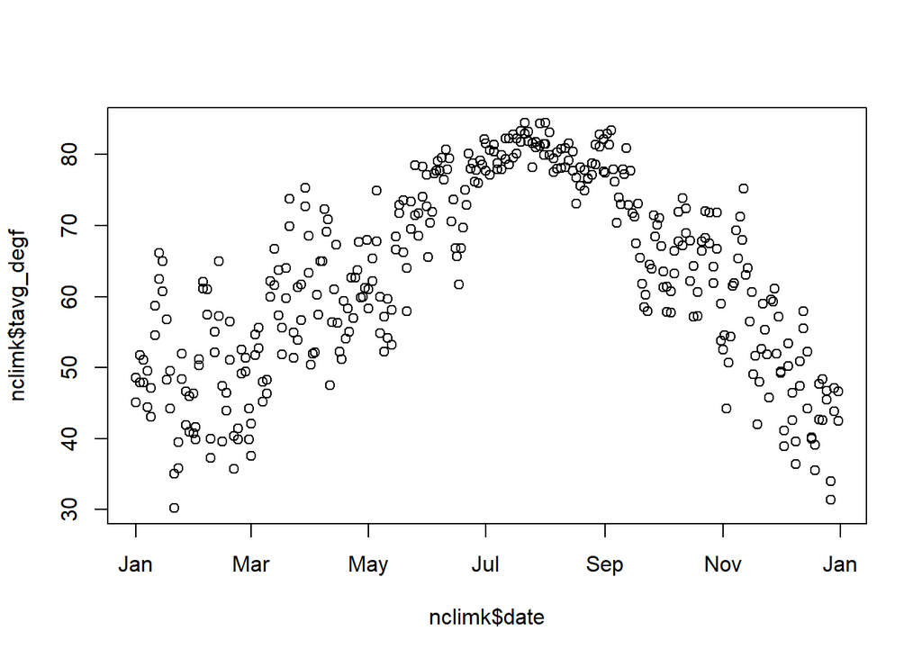

```r
##plot to the data of average tempurature w.r.t date
plot(nclimk$date,nclimk$tavg_degf)
```

```r
# data subset nclimk
# chnage the date to the day of the year!
# select the column of the date and temperature only
# omit any missing values
# inspect data
nclimk_tocluster <- nclimk %>%
    mutate(doy = yday(date)) %>%
    select(doy, tavg_degf) %>%
    na.omit()



head(nclimk_tocluster)
```

```
## # A tibble: 6 x 2
##     doy tavg_degf
##   <int>     <dbl>
## 1     1      45.1
## 2     3      47.9
## 3     5      47.9
## 4     7      44.4
## 5     9      43.1
## 6    11      54.5
```

- Now we want to set up a data frame to determine which runs

```r
# map cluster calculations function to range of k values
  temp_cluster_data <- tibble(k = 2:12) %>%
    mutate(kclust = map(k, ~calculate_cluster(nclimk_tocluster, .x))) %>%
    unnest(cols = c(kclust))

head(temp_cluster_data)
```

```
## # A tibble: 6 x 5
##       k   doy tavg_degf .cluster silhouette
##   <int> <int>     <dbl> <fct>         <dbl>
## 1     2     1      45.1 1             0.652
## 2     2     3      47.9 1             0.669
## 3     2     5      47.9 1             0.672
## 4     2     7      44.4 1             0.652
## 5     2     9      43.1 1             0.642
## 6     2    11      54.5 1             0.670
```

```r
str(temp_cluster_data)
```

```
## tibble [4,114 x 5] (S3: tbl_df/tbl/data.frame)
##  $ k         : int [1:4114] 2 2 2 2 2 2 2 2 2 2 ...
##  $ doy       : int [1:4114] 1 3 5 7 9 11 13 15 17 19 ...
##  $ tavg_degf : num [1:4114] 45.1 47.9 47.9 44.4 43.1 ...
##  $ .cluster  : Factor w/ 12 levels "1","2","3","4",..: 1 1 1 1 1 1 1 1 1 1 ...
##  $ silhouette: num [1:4114] 0.652 0.669 0.672 0.652 0.642 ...
```

```r
  # calculate average silhoutte score (highest for optimal number of k clusters)
  # for each k value
  # store these values for each value of k as temp_sil_score_data
  temp_sil_score_data <- temp_cluster_data %>%
    group_by(k) %>%
    summarize(avg_sil_score = mean(silhouette, na.rm = TRUE))
 head( temp_sil_score_data)
```

```
## # A tibble: 6 x 2
##       k avg_sil_score
##   <int>         <dbl>
## 1     2         0.467
## 2     3         0.548
## 3     4         0.527
## 4     5         0.511
## 5     6         0.475
## 6     7         0.463
```

```r
  # find maximum
  temp_optimal_sil_score_data <- temp_sil_score_data %>%
    filter(max(avg_sil_score, na.rm = TRUE) == avg_sil_score)

  # save optimal k
  temp_optimal_k_value <- temp_optimal_sil_score_data$k

  temp_optimal_k_value
```

```
## [1] 3
```

```r
#3
```

- Note we could have also used a visual inspection

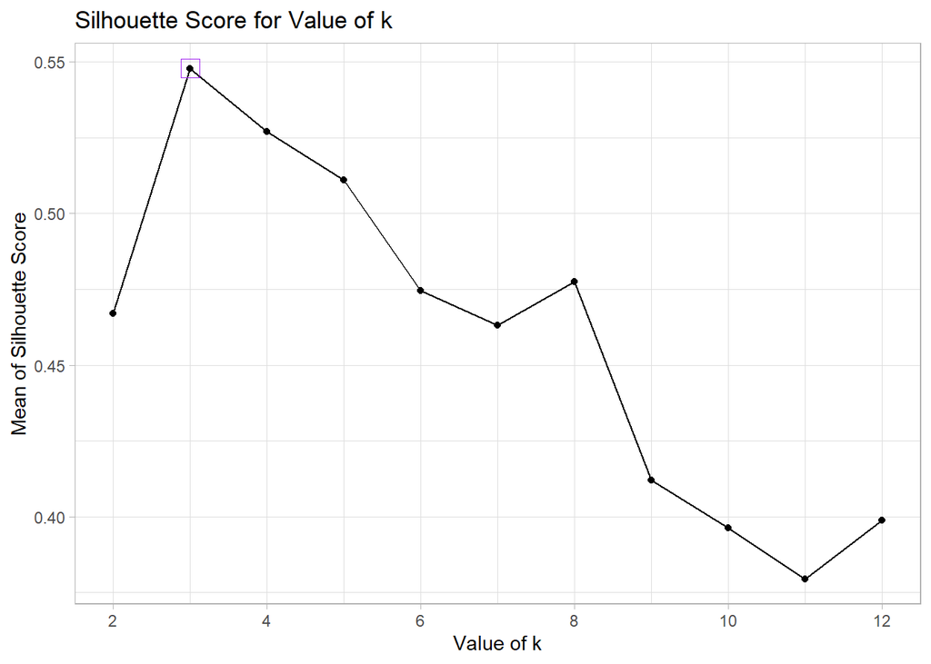

```r
# plot the data from temp_sil_score_data and visually inspect to determine the k
# with the largest sil score
# Add a marker point to visually show the max value!
temp_sil_score_data%>%
  ggplot(mapping =aes(x=k,y=avg_sil_score))+
  geom_line()+
  geom_point()+
  scale_x_continuous(breaks= pretty_breaks())+
  geom_point(data=temp_sil_score_data%>%
             filter(max(avg_sil_score)==avg_sil_score),
             pch=22,
             size=5,
             colour="purple")+
  labs(x="Value of k",y="Mean of Silhouette Score",title="Silhouette Score for Value of k")+
  theme_light()
```

```r
ggsave("Silhouette_Plot_teacher.png")
  # save optimal k cluster data as nclimk_optimal_cluster
  nclimk_optimal_cluster <- temp_cluster_data %>%
    filter(k == temp_optimal_k_value)

head(nclimk_optimal_cluster)
```

```
## # A tibble: 6 x 5
##       k   doy tavg_degf .cluster silhouette
##   <int> <int>     <dbl> <fct>         <dbl>
## 1     3     1      45.1 1             0.676
## 2     3     3      47.9 1             0.687
## 3     3     5      47.9 1             0.690
## 4     3     7      44.4 1             0.679
## 5     3     9      43.1 1             0.672
## 6     3    11      54.5 1             0.661
```

```r
tail(nclimk_optimal_cluster)
```

```
## # A tibble: 6 x 5
##       k   doy tavg_degf .cluster silhouette
##   <int> <int>     <dbl> <fct>         <dbl>
## 1     3   356      47.7 3             0.699
## 2     3   358      48.4 3             0.698
## 3     3   360      46.7 3             0.694
## 4     3   362      33.9 3             0.532
## 5     3   364      47.1 3             0.690
## 6     3   366      46.6 3             0.687
```

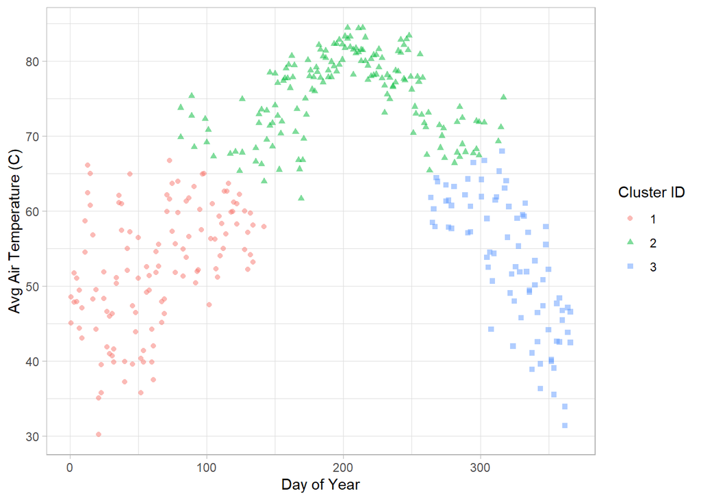

```r
# plot outputs tempavg vs doy
# color each data point by its associated cluster
ggplot(data = nclimk_optimal_cluster) +
  geom_point(aes(x = doy, y = tavg_degf, color = .cluster,shape=.cluster), alpha = 0.5) +
  labs(x = "Day of Year", y = "Avg Air Temperature (C)", color = "Cluster ID",shape = "Cluster ID")+
  theme_light()
```

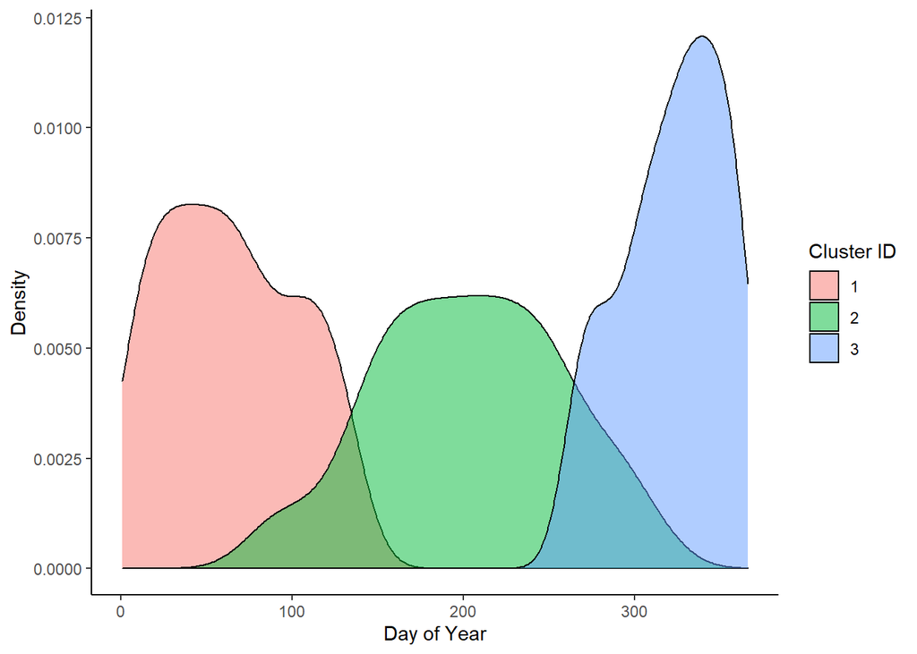

```r
# plot outputs density of doy colored by cluster
ggplot(data = nclimk_optimal_cluster) +
  geom_density(aes(x = doy, fill = .cluster), alpha = 0.5) +
  labs(x = "Day of Year", y = "Density", fill = "Cluster ID") +
  theme_classic()
```

## Bonus (for time) Content!

### PCA from ECOnet Data

```r
cardinal <- read_csv("cardinal_data.csv",
     col_types = list(`Average Air Temperature (F)` = col_number(),
         `Maximum Air Temperature (F)` = col_number(),
         `Minimum Air Temperature (F)` = col_number(),
         `Average Experimental Leaf Wetness (mV)` = col_number(),
         `Total Precipitation (in)` = col_number(),
         `Average Relative Humidity (%)` = col_number(),
         `Average Soil Moisture (m3/m3)` = col_number(),
         `Average Soil Temperature (F)` = col_number(),
         `Average Solar Radiation (W/m2)` = col_number(),
         `Average Station Pressure (mb)` = col_number()))
cardinal<-drop_na(cardinal)
str(cardinal)
```

```
## tibble [729 x 11] (S3: tbl_df/tbl/data.frame)
##  $ Date                                  : chr [1:729] "1/1/20" "1/2/20" "1/3/20" "1/4/20" ...
##  $ Average Air Temperature (F)           : num [1:729] 43.1 44.9 52.8 57.2 42.1 44.1 41.4 42.5 40.4 52 ...
##  $ Maximum Air Temperature (F)           : num [1:729] 53.6 55.4 64.9 65.1 50.5 58.5 52 57.6 50.5 65.8 ...
##  $ Minimum Air Temperature (F)           : num [1:729] 35.1 35.2 45.7 42.6 34.9 32 31.3 29.7 31.3 38.1 ...
##  $ Average Experimental Leaf Wetness (mV): num [1:729] 266 274 362 373 265 ...
##  $ Total Precipitation (in)              : num [1:729] 0 0.05 0.95 0.52 0 0 0.07 0 0 0 ...
##  $ Average Relative Humidity (%)         : num [1:729] 63.8 72 92.1 83.5 57 ...
##  $ Average Soil Moisture (m3/m3)         : num [1:729] 0.28 0.28 0.29 0.35 0.33 0.31 0.3 0.3 0.3 0.29 ...
##  $ Average Soil Temperature (F)          : num [1:729] 48.6 47.6 51 54.6 48.3 46.1 44.6 43.3 43.3 46.1 ...
##  $ Average Solar Radiation (W/m2)        : num [1:729] 134.8 66 31.1 44.9 135.4 ...
##  $ Average Station Pressure (mb)         : num [1:729] 999 1003 998 993 1005 ...
```

```r
cardinal$Date<-as.Date(cardinal$Date, tryFormats= c("%m/%d/%y"))
view(cardinal)

#changes col names
colnames(cardinal)=c("date","AvgT","MaxT","MinT","AvgLw","Tprep","AvgHum","AvgSm","AvgSt","AvgSr","AvgStp")



cardinal$IfRain<- (cardinal$Tprep>0)
cardinal$IfRain<-as.factor(as.integer(cardinal$IfRain))
```

### Basic Plotting with GGplot

[figure not shown]

```r
ggplot(cardinal,aes(x=date,y=AvgT))+geom_line()+labs(title="Total Daily Rainfall by Date",y="Average Tempurature (F) ", x= "Date")
```

- EDA is how we can motivate future ML models!
- We can use forecasting to extend this trend!

### PCA to cluster rain variable

- using cardinal data to observe *if* there is clustering
- used for future models
- helps us describe higher dimensional data with **less**

1. Remove heavily correlated columns! - Min Temp and Max Temp for a certain day will correlate with one another!
2. Center Data

Observe:

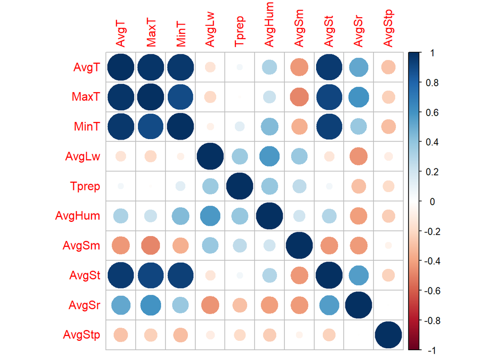

```r
library(corrplot)
corrplot(cor(cardinal[,-c(1,12)]))
```

- Tells us to remove all but one temperature variable

```r
IfRainVar<- cardinal$IfRain
cardshort <- cardinal%>%select(-c(date,IfRain,Tprep,MinT,MaxT))
cardshort
```

```
## # A tibble: 729 x 7
##     AvgT AvgLw AvgHum AvgSm AvgSt AvgSr AvgStp
##    <dbl> <dbl>  <dbl> <dbl> <dbl> <dbl>  <dbl>
##  1  43.1  266.   63.8  0.28  48.6 135.    999.
##  2  44.9  274.   72.0  0.28  47.6  66.0  1003.
##  3  52.8  362.   92.1  0.29  51    31.1   998.
##  4  57.2  373    83.5  0.35  54.6  44.9   993.
##  5  42.1  265.   57.0  0.33  48.3 135.   1005.
##  6  44.1  265.   57.6  0.31  46.1 138.   1005.
##  7  41.4  274.   75.2  0.3   44.6  40.9  1002.
##  8  42.5  314.   58.9  0.3   43.3 136.   1010.
##  9  40.4  265.   60.2  0.3   43.3 122.   1022.
## 10  52    266.   73.5  0.29  46.1  74.6  1019.
## # ... with 719 more rows
```

- We will now actually conduct PCA on our data

```r
pca_card<- princomp(scale(cardshort,scale=FALSE),cor = FALSE)
```

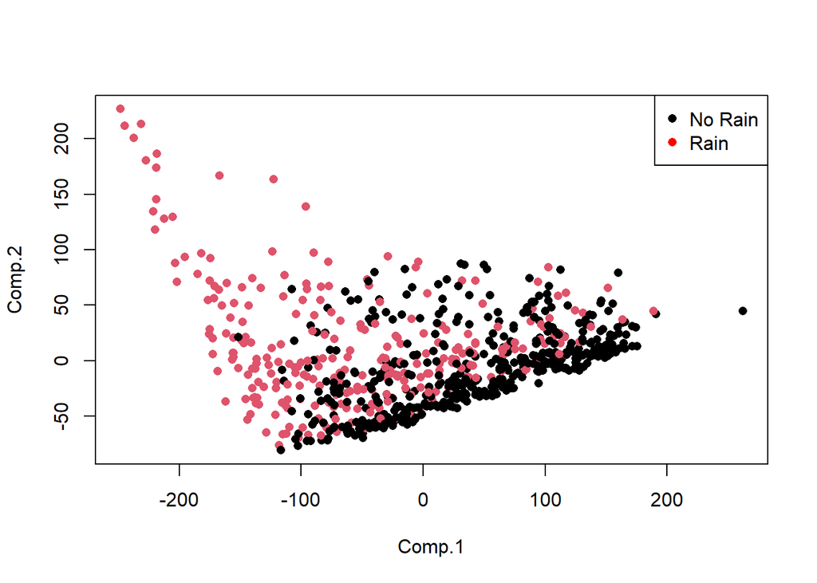

```r
plot(pca_card$scores, pch = 16, col =IfRainVar)
legend("topright",c("No Rain","Rain"),pch=16,col=c("black","red"))
```

- Here we can look at how good PCA does at describing changes in data
- We see 2 components describes 96% of the data’s variation ! (This is very good)

```r
summary(pca_card)
```

```
## Importance of components:
##                            Comp.1     Comp.2      Comp.3     Comp.4      Comp.5
## Standard deviation     93.1434884 45.4290622 18.05966455 6.31468558 5.494486034
## Proportion of Variance  0.7784786  0.1851865  0.02926584 0.00357804 0.002708918
## Cumulative Proportion   0.7784786  0.9636651  0.99293094 0.99650898 0.999217895
##                              Comp.6       Comp.7
## Standard deviation     2.9520630681 3.804718e-02
## Proportion of Variance 0.0007819752 1.298933e-07
## Cumulative Proportion  0.9999998701 1.000000e+00
```

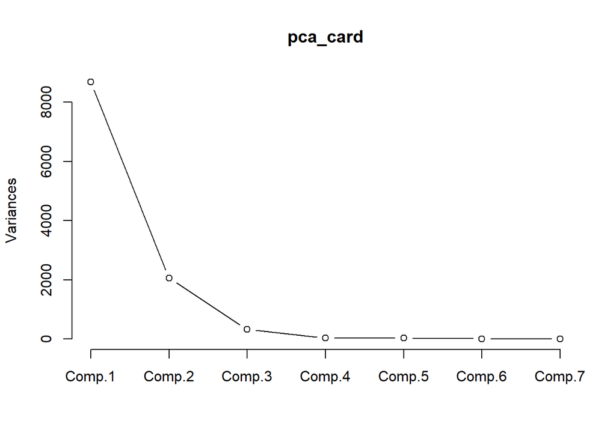

```r
screeplot(pca_card, type = "lines")
```

### How are the original variables related to the principal components?

- Does not print small values, less impactful to correlation

```r
loadings(pca_card)
```

```
##
## Loadings:
##        Comp.1 Comp.2 Comp.3 Comp.4 Comp.5 Comp.6 Comp.7
## AvgT                  0.622  0.369         0.684
## AvgLw  -0.329  0.933 -0.117
## AvgHum         0.115  0.489 -0.861
## AvgSm                                             1.000
## AvgSt                 0.582  0.318  0.182 -0.717
## AvgSr   0.936  0.325 -0.103
## AvgStp               -0.102         0.983  0.131
##
##                Comp.1 Comp.2 Comp.3 Comp.4 Comp.5 Comp.6 Comp.7
## SS loadings     1.000  1.000  1.000  1.000  1.000  1.000  1.000
## Proportion Var  0.143  0.143  0.143  0.143  0.143  0.143  0.143
## Cumulative Var  0.143  0.286  0.429  0.571  0.714  0.857  1.000
```

- The loading are simple correlations between the principal components and the original variables (Pearson’s r).
- Values closest to 1 (positive) or -1 (negative) will represent the strongest relationships, with zero being uncorrelated.

We see in PC 1 that there is a high positive correlation between AvgSr. We see the correlation between solar radiation and the component direction is quite high. So by looking at the second component or the y-axis of our previous plot: we see for the most part, Leaf wetness correlated well with the occurance of rain.

- Another visual to observe the impact of each variable on the principal component!
- Not super pretty here

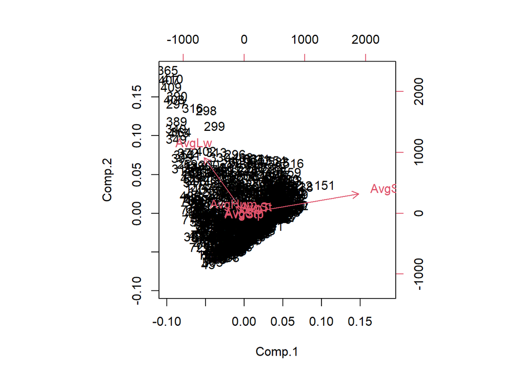

```r
biplot(pca_card)
```

## Closing & Resources

- *Define* open data and reproducible science
- *Recognize* the importance of statistical analysis for climate data analysis using cloud based data
- *Apply* techniques to access and explore publicly available climate data from the cloud using exploratory data analysis
- *Create* a machine learning model to predicts results for a representative case study

Any Questions?

### Resouces

- For a A Hydrologists Guide to Open Science, from the HESS Journal, click [here](https://hess.copernicus.org/articles/26/647/2022/).